# SHPATH

https://www.spoj.com/problems/SHPATH/  
You are given a list of cities. Each direct connection between two cities has its transportation cost (an integer bigger than 0). The goal is to find the paths of minimum cost between pairs of cities. Assume that the cost of each path (which is the sum of costs of all direct connections belonging to this path) is at most 200000. The name of a city is a string containing characters a, ..., z and is at most 10 characters long.

First I just visualize such a system, but I want to broaden the scope to be able to generate larger networks easily and be able to show them.

```python
import numpy as np
from matplotlib import pyplot as plt
import networkx as nx
```

```python
tests = 1
names = ["gdansk", "bydgoszcz", "torun", "warszawa", "lodz", "wroclaw"]
dist_cost = [[1,2,1], [1,3,3], [2,3,1], [2,4,4], [3,4,1], [4,1,2], [4,2,6], [5,3,2], [5,4,1]] #[i_city1, i_city_2, dist]
r = 2 #[the number of paths to find <= 100]
```

```python
def show_network(names, dist_cost):
    G = nx.Graph()

    #for city in names:
    #    G.add_node(city)

    for u, v, length in dist_cost:
        G.add_edge(names[u-1], names[v-1], label=length)

    #print network
    plt.figure(figsize=(16,9))
    pos = nx.circular_layout(G)
    #pos = nx.kamada_kawai_layout(G)
    nx.draw_networkx(G, pos = pos, with_label = True, node_size=600,font_size=15, #edge_color=colors,
                     node_color='y', width=2)
    nx.draw_networkx_edge_labels(G, pos)
```

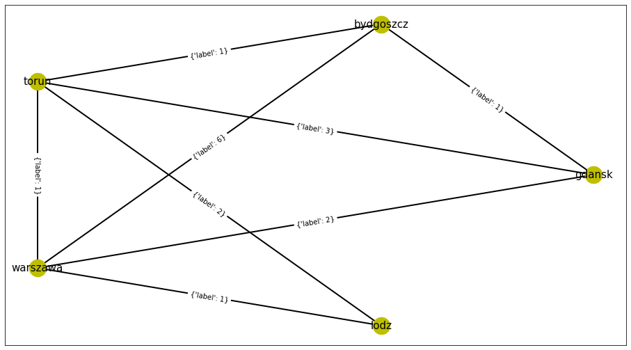

```python
show_network(names, dist_cost)
```

Networkx has various generators that allow the creation of random networks of different types.  
https://networkx.org/documentation/stable/reference/generators.html  
Here, I create a (usually) well connected Erdős-Rényi graph with a certain seed, then use Dijkstra's algorithm to calculate a shortest path between 2 nodes. If we use the same seed, the shortest path will be displayable between two different nodes afterwards.

```python
def random_erdos_with_labels(n_node, prob, seed):
    H = nx.erdos_renyi_graph(n_node, prob, seed)

    for u, v in H.edges():
        H.add_edge(u, v, label = np.random.randint(9)+1)

    plt.figure(figsize=(16,9))
    #pos = nx.circular_layout(H)
    pos = nx.kamada_kawai_layout(H)
    nx.draw_networkx(H, pos = pos, with_label = True, node_size=600,font_size=15, #edge_color=colors,
                     node_color='y', width=2)
    nx.draw_networkx_edge_labels(H, pos)

    return H
```

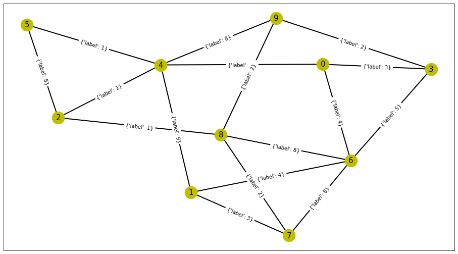

```python
H = random_erdos_with_labels(10, 0.35, None)
```

```python
def dijkstra_sequence(source, H):

    n_node = len(H.nodes())
    dist = {}
    prev = {}
    Q = []

    for v in range(n_node):
        dist.update({v: np.inf})
        prev.update({v: "null"})
        Q.append(v)
    dist[source] = 0

    #loop
    while len(Q) != 0:
        u = np.NAN
        dist_here = np.inf
        for i in Q:
            if dist[i] < dist_here:
                dist_here = dist[i]
                u = i
        Q.remove(u)

        direct_neigh = [n for n in H.neighbors(u)]
        for v in direct_neigh:
            if v in Q:
                alt = dist[u] + H.get_edge_data(u, v)["label"]
                if alt < dist[v] and dist[u] is not np.inf:
                    dist[v] = alt
                    prev[v] = u

    return dist, prev
```

```python
dist, prev = dijkstra_sequence(1, H)
```

```python
def sequence_source_to_target(source, target, dist, prev):

    S = []
    u = target

    if prev[u] in range(10) or u == source:          # Do something only if the vertex is reachable
        while u in range(10):                       # Construct the shortest path with a stack S
            S.insert(0, u)        # Push the vertex onto the stack
            u = prev[u]

    return S
```

```python
S = sequence_source_to_target(1, 7, dist, prev)
```

```python
def print_the_way(S, H):

    red_edges = []
    for i in range(len(S)-1):
        vertices = [S[i], S[i+1]]
        red_edges.append((min(vertices), max(vertices)))

    for u, v in H.edges():
        if (u,v) in red_edges:
            H.add_edge(u, v, color = 'r')
        else:
            H.add_edge(u, v, color = 'black')

    plt.figure(figsize=(16,9))
    #pos = nx.circular_layout(H)
    pos = nx.kamada_kawai_layout(H)
    colors = [H[u][v]['color'] for u,v in H.edges()]
    nx.draw_networkx(H, pos = pos, with_label = True, node_size=600,font_size=15, edge_color=colors,
                     node_color='y', width=2)
    #nx.draw_networkx_edge_labels(H, pos)

    return H
```

```
<networkx.classes.graph.Graph at 0x23fb4bd3908>
```

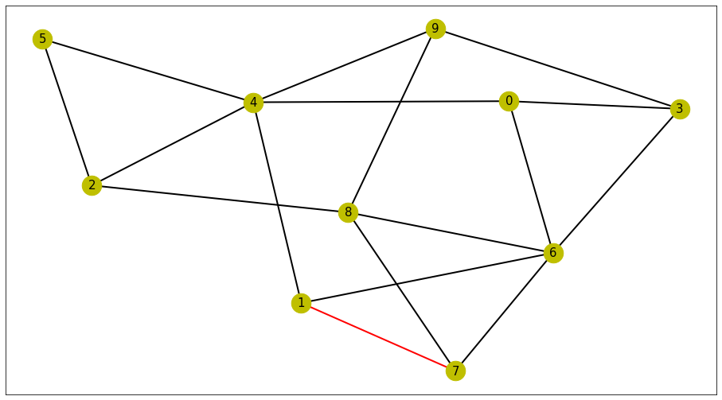

```python
print_the_way(S, H)
```

```python
def wrapper(source, target, n_node, prob, seed):
    H = random_erdos_with_labels(n_node, prob, seed) #generate and draw random graph according to the erdos-renyi model
    dist, prev = dijkstra_sequence(source, H) #dijkstra gets the fastest path to any node from the source
    S = sequence_source_to_target(source, target, dist, prev) #trace back from target to source
    print_the_way(S, H) #print resulting path highlighted
```

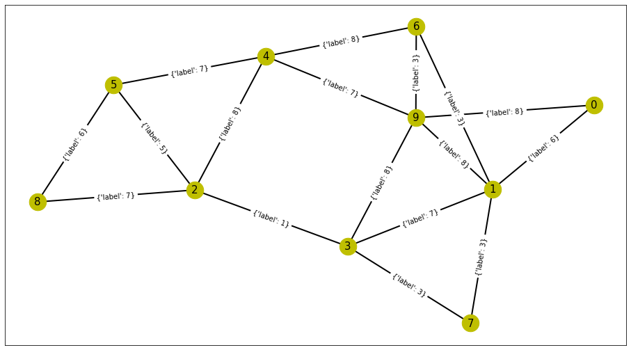

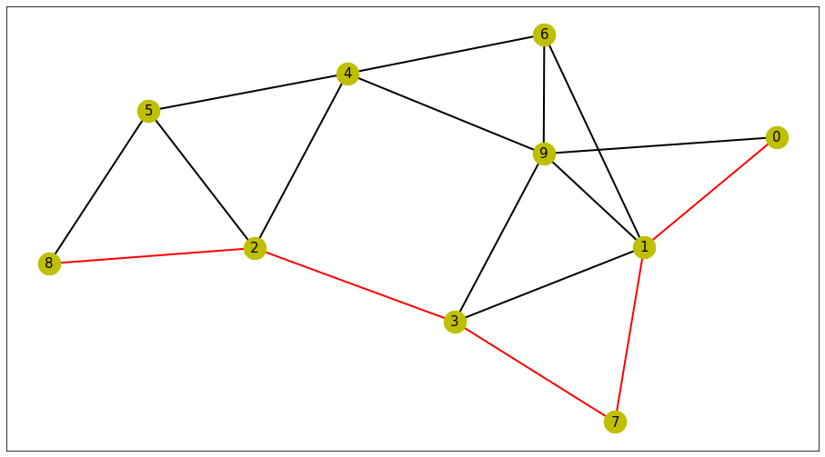

```python
wrapper(0, 8, 10, 0.4, 100)
```